[figure not shown]

# Examen tercer parcial

[figure not shown]

**Nombre:** Kevin Jaramillo  
*Fecha:* 29/06/2025  
Enlace del deber: https://github.com/Kevin06102023/matching_learning/blob/master/Examen_Tercer_parcial.ipynb https://github.com/Kevin06102023/matching_learning/blob/master/res/.ipynb_checkpoints/movie_genre_classification_final-checkpoint.csv

# Examen del Tercer Parcial

## Regresión lineal

Dado el archivo **movie_genre_classification_final.csv** se encuentra un base de datos con información de **50000 películas** que incluyen variables como:

- Título,
- Año de estreno,
- Duración,
- Puntuación promedio,
- Número de votos,
- Presupuesto,
- Ingresos en taquilla,
- Número de premios obtenidos,
- Entre otras caracterisiticas. Como parate del análisis de predicción, se desea estudiar la relación entre el:
- Presupuesto de una película y sus caracteristicas cuantitativas, para estimar la **recaudación en taquilla (BoxOffice_USD)**. Para ello, se plantea entrenar un modelo de regresión lineal.

# Objetivo

Predecir el valor de la variable **BoxOffice_USD** a partir de variables numéricas independientes disponibles en el dataset, tales como:

- Budget_USD (Presupuesto en dólares)
- Duration (Duración en minutos)
- Ratting (Calificiación Promedio"
- Votes (Número de votos)
- Num_Awards (Número de premios obtenidos)
- Critic_reviews (Números de reseñas de criticos)

El dataset fue extraido desder DataSet

## Entrega esperada

```python
# Lectura de datos
import pandas as pd
#Cargar el archivo CSV
df = pd.read_csv('res/movie_genre_classification_final.csv')
#Mostrar las primeras filas para verificar la carga
print(df.head())
#Mostrar la información para observar el tipo de datos y si existe valores nulos
print(df.info())
```

```
             Title  Year  Director  Duration  Rating   Votes  \
0  Winds of Fate 4  1980    R. Lee       167     4.1  182425
1     Firestorm 11  2014   S. Chen       166     4.1  449351
2    Silent Echo 2  2016   A. Khan       170     4.1  363328
3    City Lights 4  1982  L. Zhang       170     9.9   62371
4   Broken Truth 1  1990  L. Zhang        91     5.3    4600

                                         Description  Language Country  \
0   A touching love story with heartwarming moments.   Spanish   China
1  A fast-paced thriller with intense action scenes.    Korean   China
2  A fast-paced thriller with intense action scenes.    Korean   Japan
3  An emotional journey exploring complex charact...  Japanese   Japan
4  An imaginative world filled with magic and won...    Korean     USA

   Budget_USD  BoxOffice_USD    Genre Production_Company Content_Rating  \
```

[output cut: 37 more lines]

```
         Budget_USD     Duration        Rating          Votes    Num_Awards  \
count  5.000000e+04  50000.00000  50000.000000   50000.000000  50000.000000
mean   9.179143e+07    130.07312      6.926472  249699.050540      9.964440
std    5.823888e+07     29.11097      1.698758  144314.043032      6.066303
min    1.135566e+06     80.00000      4.000000     516.000000      0.000000
25%    4.389040e+07    105.00000      5.500000  124531.500000      5.000000
50%    8.062480e+07    130.00000      6.900000  248582.000000     10.000000
75%    1.475557e+08    155.00000      8.400000  374833.500000     15.000000
max    1.984445e+08    180.00000      9.900000  499984.000000     20.000000

       Critic_Reviews  BoxOffice_USD
count    50000.000000   5.000000e+04
mean       500.176380   5.176063e+08
std        289.971792   2.880283e+08
min          0.000000   3.291117e+06
25%        248.000000   2.590329e+08
50%        500.000000   5.109973e+08
75%        751.000000   7.704129e+08
max       1000.000000   9.925159e+08
```

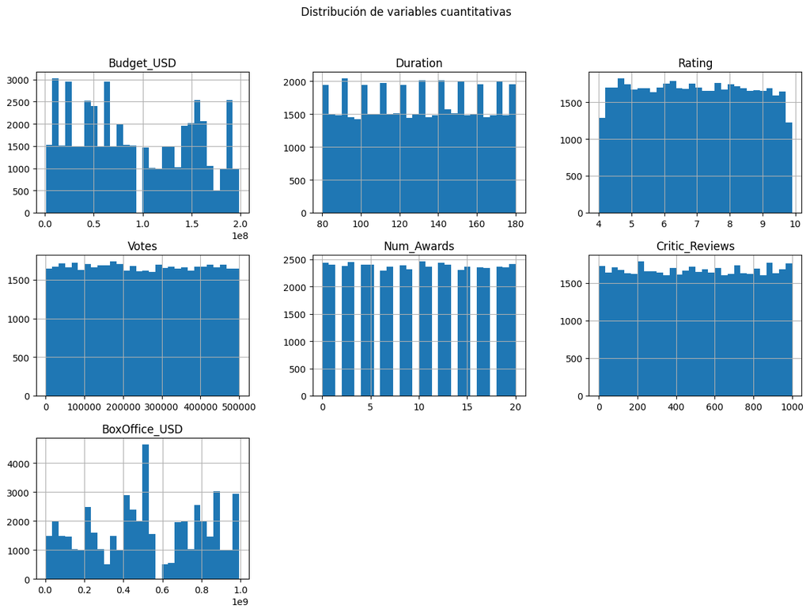

```python
# Visualización del conjunto de datos
import matplotlib.pyplot as plt
import seaborn as sns
#Estadísticas descriptivas de las variables
variables = ['Budget_USD', 'Duration', 'Rating', 'Votes', 'Num_Awards', 'Critic_Reviews', 'BoxOffice_USD']
print(df[variables].describe())
#Histograma para observar la distribución de las variables
df[variables].hist(bins=30, figsize=(15,10))
plt.suptitle('Distribución de variables cuantitativas')
plt.show()
```

```python
# Modificación del conjunto de datos
# Seleccionamos las columnas necesarias
df_model = df[variables].copy()
# Revisamos si hay valores faltantes
print(df_model.isnull().sum())
# Eliminamos filas con datos faltantes
df_model = df_model.dropna()
# Revisamos los cambios
print(f'Datos después de eliminar nulos: {df_model.shape}')
# Cálculo de medias para cada variable independiente
medias = df_model[variables[:-1]].mean()
```

```
Budget_USD        0
Duration          0
Rating            0
Votes             0
Num_Awards        0
Critic_Reviews    0
BoxOffice_USD     0
dtype: int64
Datos después de eliminar nulos: (50000, 7)
```

```
Error cuadrático medio (MSE): 83696224592480560.00
Coeficiente de determinación (R^2): -0.0005

Coeficientes del modelo:
         Variable   Coeficiente
0      Budget_USD  5.271781e-03
1        Duration -8.788019e+04
2          Rating -1.214600e+06
3           Votes  1.368880e+00
4      Num_Awards  5.981463e+05
5  Critic_Reviews  3.789158e+03
```

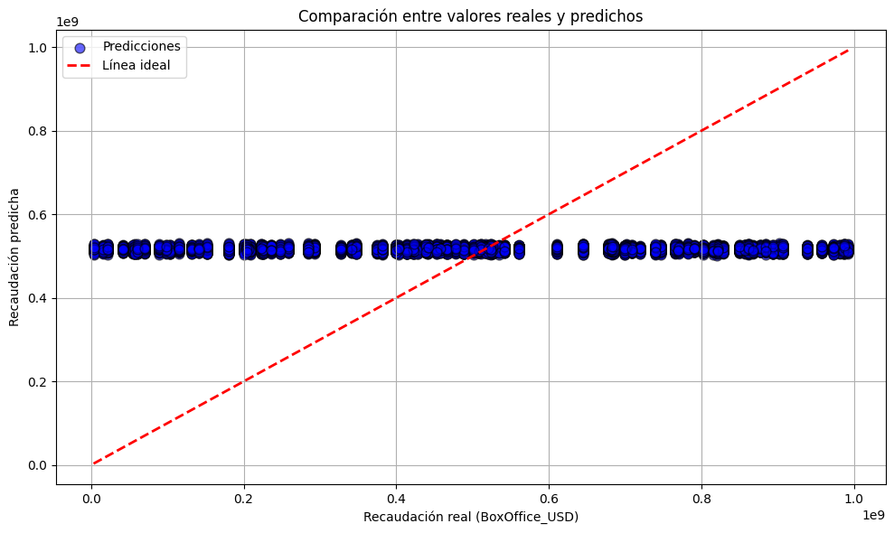

```python
#Construcción del modelo de regresión lineal
from sklearn.model_selection import train_test_split
from sklearn.linear_model import LinearRegression
from sklearn.metrics import mean_squared_error, r2_score
import pandas as pd
import matplotlib.pyplot as plt
# Definir variables independientes (X) y dependiente (y)
X = df_model.drop('BoxOffice_USD', axis=1)
y = df_model['BoxOffice_USD']
# Dividir datos en entrenamiento y prueba
X_train, X_test, y_train, y_test = train_test_split(
    X, y, test_size=0.2, random_state=42)
# Crear y entrenar el modelo
model = LinearRegression()
model.fit(X_train, y_train)
# Predecir sobre el conjunto de prueba
y_pred = model.predict(X_test)
# Evaluar el modelo
mse = mean_squared_error(y_test, y_pred)
r2 = r2_score(y_test, y_pred)
print(f'Error cuadrático medio (MSE): {mse:.2f}')
print(f'Coeficiente de determinación (R^2): {r2:.4f}')
# Mostrar los coeficientes del modelo
coef_df = pd.DataFrame({
    'Variable': X.columns,
    'Coeficiente': model.coef_
})
print("\nCoeficientes del modelo:")
print(coef_df)
# Gráfico
plt.figure(figsize=(10,6))
# Gráfico de dispersión (puntos)
plt.scatter(y_test, y_pred, alpha=0.6, color='blue', edgecolors='k', s=60, label='Predicciones')
# Línea roja de referencia (predicción perfecta)
min_val = min(y_test.min(), y_pred.min())
max_val = max(y_test.max(), y_pred.max())
plt.plot([min_val, max_val], [min_val, max_val], color='red', linestyle='--', linewidth=2, label='Línea ideal')
# Estética del gráfico
plt.xlabel('Recaudación real (BoxOffice_USD)')
plt.ylabel('Recaudación predicha')
plt.title('Comparación entre valores reales y predichos')
plt.legend()
plt.grid(True)
plt.tight_layout()
plt.show()
```

```
Película 1 - Predicción de recaudación: $510,874,771.20
Película 2 - Predicción de recaudación: $513,731,243.39
Película 3 - Predicción de recaudación: $509,493,076.08
```

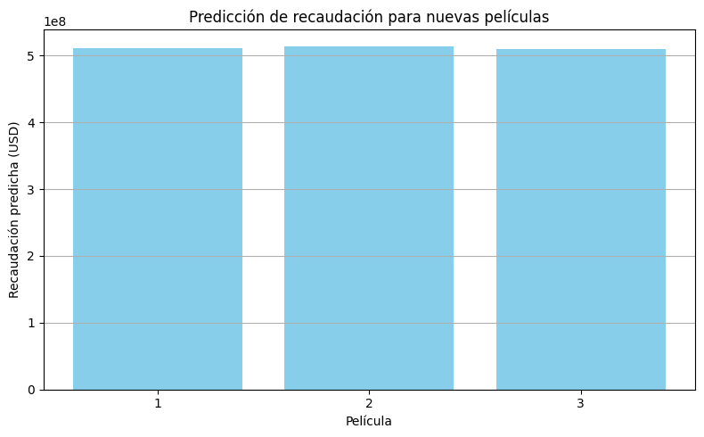

```python
# Predicción de nuevos ejemplos
import pandas as pd
import matplotlib.pyplot as plt
# Nuevos ejemplos para predecir
nuevas_peliculas = [
    {'Budget_USD': 50000000, 'Duration': 120, 'Rating': 7.5, 'Votes': 100000, 'Num_Awards': 3, 'Critic_Reviews': 80},
    {'Budget_USD': 20000000, 'Duration': 90, 'Rating': 6.0, 'Votes': 30000, 'Num_Awards': 1, 'Critic_Reviews': 40},
    {'Budget_USD': 100000000, 'Duration': 150, 'Rating': 8.0, 'Votes': 200000, 'Num_Awards': 5, 'Critic_Reviews': 150},
]
# Convertir a DataFrame
nuevo_df = pd.DataFrame(nuevas_peliculas)
# Realizar predicciones
predicciones = model.predict(nuevo_df)
# Mostrar resultados
for i, pred in enumerate(predicciones):
    print(f"Película {i+1} - Predicción de recaudación: ${pred:,.2f}")
#  Gráfico de barras con las predicciones
plt.figure(figsize=(8,5))
plt.bar(range(1, len(predicciones)+1), predicciones, color='skyblue')
plt.xlabel('Película')
plt.ylabel('Recaudación predicha (USD)')
plt.title('Predicción de recaudación para nuevas películas')
plt.xticks(range(1, len(predicciones)+1))
plt.grid(axis='y')
plt.tight_layout()
plt.show()
```